# 2023-05-25-Bayesian-LMM

M.G. Erickson

2023-05-26

# Load packages

```r
# Load packages-----------------------------------------------------------------
library(readxl)
library(tidyverse)
library(lmerTest)
library(emmeans)
library(ggplot2)
library(kableExtra)
library(nlme)
library(MAW636)
library(broom.mixed)
library(brms)
library(sjPlot)
theme_set(theme_bw())
```

# Load data

Converting to factor may help brms run faster.

```r
phdat <- read.csv("01_organize/rumen_imp 2023.02.13 backup.csv")%>%
  mutate(cow = as.character(cow),
         hr = as.factor(hr),
         period = factor(period, levels = c(paste0("P", 1:4))),
         day = factor(day, levels = c(paste0("Day", 1:4)))) %>%
  dplyr::select( period, day, hr, cow, osc_lvl, prot_lvl, trt, rumen_ph)

str(phdat)
```

```
## 'data.frame':    640 obs. of  8 variables:
##  $ period  : Factor w/ 4 levels "P1","P2","P3",..: 1 2 3 4 1 2 3 4 1 2 ...
##  $ day     : Factor w/ 4 levels "Day1","Day2",..: 1 1 1 1 2 2 2 2 3 3 ...
##  $ hr      : Factor w/ 5 levels "6","8","10","12",..: 2 2 2 2 2 2 2 2 2 2 ...
##  $ cow     : chr  "8810" "8810" "8810" "8810" ...
##  $ osc_lvl : chr  "S" "S" "O" "O" ...
##  $ prot_lvl: chr  "LP" "HP" "HP" "LP" ...
##  $ trt     : chr  "SLP" "SHP" "OHP" "OLP" ...
##  $ rumen_ph: num  6.51 6.67 6.94 6.29 6.42 ...
```

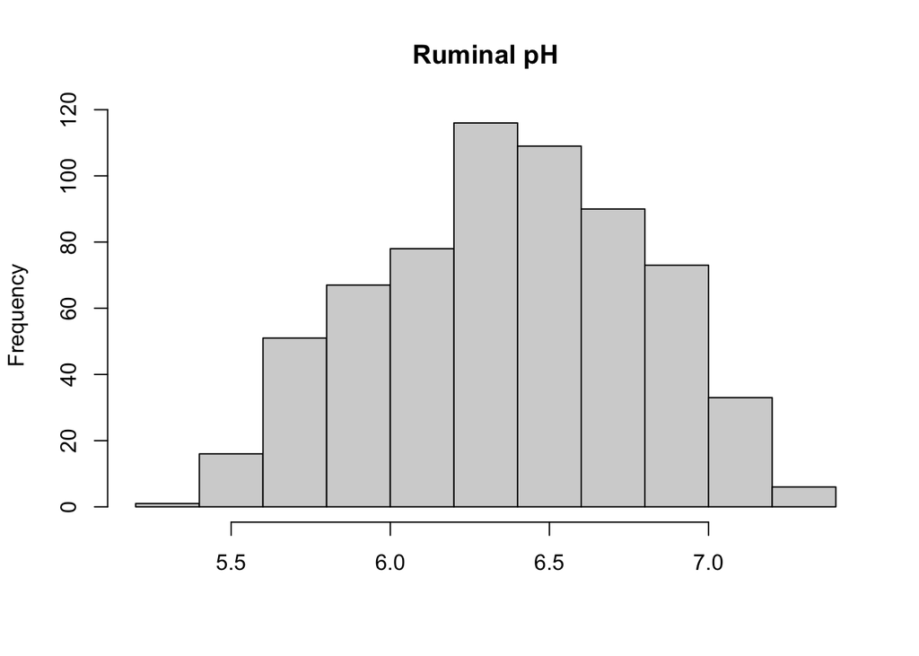

```r
hist(phdat$rumen_ph, main = "Ruminal pH", xlab = NULL)
```

# Fit LMM Frequentist

## ANOVA style Expression

Same as from production manuscript, except that there are more levels to Hour (5 instead of 2), and there is no cannulated effect. More similar to intensive manuscript plasma model. Because there are 5 observations with a cow x period x day, there is an AR1 structure. This was not implemented with total collections or plasma data because of having only 2 or 3 observations to model.Selected on the basis of BIC.

The ANOVA expression emphasizes that we are modeling conditional means, i.e., means at different levels of the indexes i j k l m n.

$$\begin{aligned}
y_{i j k l m n}=\mu+ & E_j+P_k+F_l+P F_{k l}+D_m+H_n+\left(D_m
\times H_n\right) \\
& +D_m\left(P_k+F_l+P F_{k l}\right) \\
& +H_n\left(P_k+F_l+P F_{k l}\right) \\
& +\left(D_m \times H_n\right)\left(P_k+F_l+P F_{k l}\right) \\
& +C_i+(C: E)_{i j}+(C: E: D)_{i j m}+\epsilon_{i j k l m n}
\end{aligned}$$

Complete model:  
experimental period (Ek, where k = 1, 2, 3, 4).  
dietary CP level (Pl, where l = LP, HP). CP feeding pattern (Fm, where m = OF, SF). Interaction term between CP level and CP feeding pattern.  
Random effect of cow (i = 1 to 9).  
Random error term (ϵijklm; n = 640).

Actual model has missingness (2.6% of observations) imputed, and 2 of 32 cow:periods omitted (and not imputed).

## lme() Expression

```r
model_f = lme(rumen_ph ~ period + osc_lvl * prot_lvl * day * hr,
    random = ~ 1 | cow / period / day,
    correlation = corAR1(form = ~ 1 | cow / period / day), data = phdat,
    control = lmeControl(opt = "optim")
  )
# summary(model_f, verbose = F) omitted, too verbose
tab_model(model_f)
```

|  | rumen ph |  |  |
| --- | --- | --- | --- |
| Predictors | Estimates | CI | p |
| (Intercept) | 6.56 | 6.37 – 6.75 | **<0.001** |
| period [P2] | 0.08 | 0.01 – 0.15 | **0.036** |
| period [P3] | -0.02 | -0.10 – 0.05 | 0.550 |
| period [P4] | 0.18 | 0.10 – 0.26 | **<0.001** |
| osc lvl [S] | 0.12 | -0.14 – 0.38 | 0.345 |
| prot lvl [LP] | 0.08 | -0.18 – 0.34 | 0.505 |
| day [Day2] | 0.06 | -0.19 – 0.30 | 0.630 |
| day [Day3] | 0.11 | -0.14 – 0.35 | 0.381 |
| day [Day4] | -0.04 | -0.29 – 0.20 | 0.726 |
| hr [8] | 0.28 | 0.05 – 0.51 | **0.016** |
| hr [10] | -0.23 | -0.46 – -0.00 | **0.049** |
| hr [12] | -0.45 | -0.68 – -0.22 | **<0.001** |
| hr [19] | -0.78 | -1.00 – -0.57 | **<0.001** |
| osc lvl [S] × prot lvl [LP] | -0.13 | -0.49 – 0.24 | 0.479 |
| osc lvl [S] × day [Day2] | -0.16 | -0.51 – 0.18 | 0.352 |
| osc lvl [S] × day [Day3] | -0.25 | -0.60 – 0.10 | 0.155 |
| osc lvl [S] × day [Day4] | -0.11 | -0.46 – 0.24 | 0.528 |
| prot lvl [LP] × day [Day2] | -0.15 | -0.49 – 0.20 | 0.397 |
| prot lvl [LP] × day [Day3] | -0.12 | -0.47 – 0.23 | 0.493 |
| prot lvl [LP] × day [Day4] | 0.14 | -0.21 – 0.49 | 0.423 |
| osc lvl [S] × hr [8] | -0.30 | -0.62 – 0.03 | 0.073 |
| osc lvl [S] × hr [10] | -0.14 | -0.46 – 0.19 | 0.412 |
| osc lvl [S] × hr [12] | -0.09 | -0.42 – 0.23 | 0.567 |
| osc lvl [S] × hr [19] | -0.10 | -0.40 – 0.20 | 0.506 |
| prot lvl [LP] × hr [8] | -0.36 | -0.69 – -0.04 | **0.028** |
| prot lvl [LP] × hr [10] | -0.15 | -0.47 – 0.18 | 0.375 |
| prot lvl [LP] × hr [12] | -0.24 | -0.56 – 0.08 | 0.148 |
| prot lvl [LP] × hr [19] | -0.04 | -0.34 – 0.26 | 0.775 |
| day [Day2] × hr [8] | -0.05 | -0.38 – 0.27 | 0.740 |

[output cut: 64 more lines]

Optimizer changed to optim due to convergence issues with default.

## Matrix Expression

$$\mathbf{Y = XB + Z\gamma + {\varepsilon}}$$
where - $y$ is the $n$-by-1 response vector, and $n$ is the number of observations. - $X$ is an $n$-by-p fixed-effects design matrix. - $B$ is a $p$-by-1 fixed-effects vector. - $Z$ is an $n$-by- $q$ random-effects design matrix. - $\gamma$ is a $q$-by-1 random-effects vector. - $\varepsilon$ is the $n$-by-1 observation error vector.

where the expectation of the random effect and error means are zero.
$$E\begin{pmatrix}\gamma \\ \varepsilon \end{pmatrix} = \begin{bmatrix}0
\\ 0 \end{bmatrix}$$
Because the other parts (e.g., X, B) are fixed and do not vary, we only talk about the variance covariance matrix of the random effects and error term. These are assumed to be independent.
$$var\begin{pmatrix}\gamma \\ \varepsilon
\end{pmatrix} = \begin{bmatrix} \mathbf{G}& O \\ O & \mathbf{R}
\end{bmatrix}$$
The R matrix is structured such that the covariance between an observation at time ti and time ti’ is:

$$\frac{\sigma^2}{1-\phi^2}\phi^{|t_i-t_{i'}|}$$

```r
# example
delta <- c(0,1,3,4,8) # time difference
phi <- .5 # autocorrelation parameter
sigma <- 1 #
t <- cumsum(delta);t
```

```
## [1]  0  1  4  8 16
```

```r
outer(t, t, "-")
```

```
##      [,1] [,2] [,3] [,4] [,5]
## [1,]    0   -1   -4   -8  -16
## [2,]    1    0   -3   -7  -15
## [3,]    4    3    0   -4  -12
## [4,]    8    7    4    0   -8
## [5,]   16   15   12    8    0
```

```r
Sigma <- sigma^2/(1-phi^2)*phi^abs(outer(t,t,"-"))
Sigma
```

```
##              [,1]         [,2]         [,3]        [,4]         [,5]
## [1,] 1.333333e+00 0.6666666667 0.0833333333 0.005208333 2.034505e-05
## [2,] 6.666667e-01 1.3333333333 0.1666666667 0.010416667 4.069010e-05
## [3,] 8.333333e-02 0.1666666667 1.3333333333 0.083333333 3.255208e-04
## [4,] 5.208333e-03 0.0104166667 0.0833333333 1.333333333 5.208333e-03
## [5,] 2.034505e-05 0.0000406901 0.0003255208 0.005208333 1.333333e+00
```

Where phi is the autocorrelation parameter.

# Fit LMM Bayesian

## Model Expression

The model has the same form, except we will specify priors.

NOTE: this is a different mu than before! I am trying to write this out but not sure if I got it correct yet. I tried to stay away from Greek letters to make it simpler to translate and match with the frequentist version. Term order is a little different. Assuming the alpha is separate from the X matrix is not typical.

B, alpha, sigma e are population level terms. I’m not sure if it is typical to express mu indexed.

There is probably a way to set a prior on the autocorrelation parameter but I haven’t found how to change the default.

$$\begin{aligned}
y_{i j k l m n} &\sim Normal(\mu_{i j k l m n}, \sigma) \\
\mu_{i j k l m n} &= \alpha + \mathbf{XB} + C_i+(C: E)_{i j}+(C: E:
D)_{i j m} \\
C_i &\sim Normal(0,\sigma_{C_i } ) \\
(C: E_{i j}) &\sim Normal(0,\sigma_{(C: E_{i j}) }) \\
(C: E: D)_{i j m} &\sim Normal(0,\sigma_{(C: E: D)_{i j m}}) \\
\alpha &\sim Normal(7,10) \\
\text{class of B } &\sim Normal(0,10) \\
\sigma_{e} &\sim HalfCauchy(0,10) \\
\sigma_{C_i } &\sim HalfCauchy(0,10) \\
\sigma_{(C: E_{i j}) }&\sim HalfCauchy(0,10) \\
\sigma_{(C: E: D)_{i j m}}&\sim HalfCauchy(0,10) \\
\end{aligned}$$
In this case, there is a global intercept modeled (alpha) that is analogous to the mu in the prior notation. ANOVA notation does not express coefficients separately, so I just used XB matrix notation to describe the fixed effects.

X are still assumed fixed and known. The variance components are independent so there is no need to specify a covariance matrix describing the relations between intercept/slope. The Ci, C:E, C:E:D could also be considered part of class alpha.

The global intercept variance is separate than the error term, so they get different priors.

The sigma term in the first expression is the entire variance which includes variance components.

Priors should be **realistic** given scientific knowledge. For example, we know pH will be from 0 to 14.

### Get priors using lme syntax

```r
## get all parameters and parameters classes to define priors on
prior <- get_prior(
  rumen_ph~period + osc_lvl * prot_lvl * day * hr + (1|cow/period/day) +
    ar(gr = cow:period:day),
            data = phdat, family = gaussian())
prior
```

```
##                   prior     class                             coef
##                  (flat)        ar
##                  (flat)         b
##                  (flat)         b                          dayDay2
##                  (flat)         b                     dayDay2:hr10
##                  (flat)         b                     dayDay2:hr12
##                  (flat)         b                     dayDay2:hr19
##                  (flat)         b                      dayDay2:hr8
##                  (flat)         b                          dayDay3
##                  (flat)         b                     dayDay3:hr10
##                  (flat)         b                     dayDay3:hr12
##                  (flat)         b                     dayDay3:hr19
##                  (flat)         b                      dayDay3:hr8
##                  (flat)         b                          dayDay4
##                  (flat)         b                     dayDay4:hr10
##                  (flat)         b                     dayDay4:hr12
##                  (flat)         b                     dayDay4:hr19
##                  (flat)         b                      dayDay4:hr8
##                  (flat)         b                             hr10
##                  (flat)         b                             hr12
##                  (flat)         b                             hr19
##                  (flat)         b                              hr8
##                  (flat)         b                         osc_lvlS
##                  (flat)         b                 osc_lvlS:dayDay2
##                  (flat)         b            osc_lvlS:dayDay2:hr10
##                  (flat)         b            osc_lvlS:dayDay2:hr12
##                  (flat)         b            osc_lvlS:dayDay2:hr19
##                  (flat)         b             osc_lvlS:dayDay2:hr8
##                  (flat)         b                 osc_lvlS:dayDay3
##                  (flat)         b            osc_lvlS:dayDay3:hr10
##                  (flat)         b            osc_lvlS:dayDay3:hr12
##                  (flat)         b            osc_lvlS:dayDay3:hr19
##                  (flat)         b             osc_lvlS:dayDay3:hr8
##                  (flat)         b                 osc_lvlS:dayDay4
##                  (flat)         b            osc_lvlS:dayDay4:hr10
##                  (flat)         b            osc_lvlS:dayDay4:hr12
##                  (flat)         b            osc_lvlS:dayDay4:hr19
##                  (flat)         b             osc_lvlS:dayDay4:hr8
##                  (flat)         b                    osc_lvlS:hr10
##                  (flat)         b                    osc_lvlS:hr12
```

[output cut: 133 more lines]

```
##                                       (vectorized)
##                                       (vectorized)
##                                       (vectorized)
##                                       (vectorized)
##                                       (vectorized)
##                                       (vectorized)
##                                            default
##                                  0         default
##             cow                  0    (vectorized)
##             cow                  0    (vectorized)
##      cow:period                  0    (vectorized)
##      cow:period                  0    (vectorized)
##  cow:period:day                  0    (vectorized)
##  cow:period:day                  0    (vectorized)
##                                  0         default
```

### Set priors

You can set priors to an entire class of parameters (e.g., sd, b, sigma) or to individual coefficients. When cauchy() is applied to sd or sigma, it is actually a half-cauchy, so the variance parameters are constrained to positive. Cauchy has thicker tails than a normal distribution so it seems like this allows for more abberrant observations. We will set weak priors.

```r
prior3 = c(
  prior(normal(7,10), class = Intercept),
  prior(normal(0,10), class = b), # speeds up relative to default flat prior
  prior(cauchy(0,10), class = sd), # variance components
  prior(cauchy(0,10), class = sigma) # residual variance
)
```

## brms() Expression

Cut iterations to 5000 for speed because this is just for fun.

```r
t1 = Sys.time()
bmod3 = brm(rumen_ph~period + osc_lvl * prot_lvl * day * hr + (1|cow/period/day) +
    ar(gr = cow:period:day),
            data = phdat, family = gaussian(),
            prior = prior3,
            warmup = 2000, iter = 5000)
```

```
## Trying to compile a simple C file
```

[output not shown]

```r
t2 = Sys.time()
#summary(bmod3)
tab_model(bmod3)
```

|  | rumen ph |  |
| --- | --- | --- |
| Predictors | Estimates | CI (95%) |
| Intercept | 6.56 | 6.37 – 6.76 |
| periodP2 | 0.08 | 0.00 – 0.16 |
| periodP3 | -0.02 | -0.10 – 0.06 |
| periodP4 | 0.18 | 0.10 – 0.26 |
| osc_lvlS | 0.12 | -0.12 – 0.36 |
| prot_lvlLP | 0.08 | -0.16 – 0.33 |
| dayDay2 | 0.06 | -0.19 – 0.30 |
| dayDay3 | 0.11 | -0.13 – 0.35 |
| dayDay4 | -0.04 | -0.29 – 0.20 |
| hr: hr 8 | 0.28 | 0.04 – 0.51 |
| hr: hr 10 | -0.23 | -0.46 – 0.00 |
| hr: hr 12 | -0.45 | -0.67 – -0.22 |
| hr: hr 19 | -0.79 | -1.00 – -0.57 |
| osc_lvlS:prot_lvlLP | -0.13 | -0.47 – 0.21 |
| osc_lvlS:dayDay2 | -0.16 | -0.50 – 0.17 |
| osc_lvlS:dayDay3 | -0.25 | -0.59 – 0.10 |
| osc_lvlS:dayDay4 | -0.11 | -0.45 – 0.23 |
| prot_lvlLP:dayDay2 | -0.15 | -0.48 – 0.20 |
| prot_lvlLP:dayDay3 | -0.12 | -0.46 – 0.23 |
| prot_lvlLP:dayDay4 | 0.14 | -0.20 – 0.48 |
| osc_lvlS:hr8 | -0.30 | -0.62 – 0.04 |
| osc_lvlS:hr10 | -0.14 | -0.46 – 0.19 |
| osc_lvlS:hr12 | -0.10 | -0.41 – 0.22 |
| osc_lvlS:hr19 | -0.10 | -0.41 – 0.20 |
| prot_lvlLP:hr8 | -0.36 | -0.69 – -0.03 |
| prot_lvlLP:hr10 | -0.15 | -0.48 – 0.18 |
| prot_lvlLP:hr12 | -0.24 | -0.56 – 0.08 |
| prot_lvlLP:hr19 | -0.04 | -0.35 – 0.26 |
| dayDay2:hr8 | -0.05 | -0.38 – 0.27 |

[output cut: 63 more lines]

## Time elapsed

```r
t2 - t1
```

```
## Time difference of 5.27798 mins
```

## See Stan code

This is what is compiled at runtime. Unclear if brms will cache this (don’t think so). Maybe helpful for getting correct model expression?

```r
stancode(bmod3)
```

```
## // generated with brms 2.19.0
## functions {
## }
## data {
##   int<lower=1> N;  // total number of observations
##   vector[N] Y;  // response variable
##   int<lower=1> K;  // number of population-level effects
##   matrix[N, K] X;  // population-level design matrix
##   // data needed for ARMA correlations
##   int<lower=0> Kar;  // AR order
##   int<lower=0> Kma;  // MA order
##   // number of lags per observation
##   int<lower=0> J_lag[N];
##   // data for group-level effects of ID 1
##   int<lower=1> N_1;  // number of grouping levels
##   int<lower=1> M_1;  // number of coefficients per level
##   int<lower=1> J_1[N];  // grouping indicator per observation
##   // group-level predictor values
##   vector[N] Z_1_1;
##   // data for group-level effects of ID 2
##   int<lower=1> N_2;  // number of grouping levels
##   int<lower=1> M_2;  // number of coefficients per level
##   int<lower=1> J_2[N];  // grouping indicator per observation
##   // group-level predictor values
##   vector[N] Z_2_1;
##   // data for group-level effects of ID 3
##   int<lower=1> N_3;  // number of grouping levels
##   int<lower=1> M_3;  // number of coefficients per level
##   int<lower=1> J_3[N];  // grouping indicator per observation
##   // group-level predictor values
##   vector[N] Z_3_1;
##   int prior_only;  // should the likelihood be ignored?
## }
## transformed data {
##   int Kc = K - 1;
##   matrix[N, Kc] Xc;  // centered version of X without an intercept
##   vector[Kc] means_X;  // column means of X before centering
##   int max_lag = max(Kar, Kma);
##   for (i in 2:K) {
##     means_X[i - 1] = mean(X[, i]);
```

[output cut: 52 more lines]

```
##       }
##       mu[n] += Err[n, 1:Kar] * ar;
##     }
##     target += normal_lpdf(Y | mu, sigma);
##   }
##   // priors including constants
##   target += lprior;
##   target += std_normal_lpdf(z_1[1]);
##   target += std_normal_lpdf(z_2[1]);
##   target += std_normal_lpdf(z_3[1]);
## }
## generated quantities {
##   // actual population-level intercept
##   real b_Intercept = Intercept - dot_product(means_X, b);
## }
```

## Diagnostics

```r
pp_check(bmod3)
```

```
## Using 10 posterior draws for ppc type 'dens_overlay' by default.
```

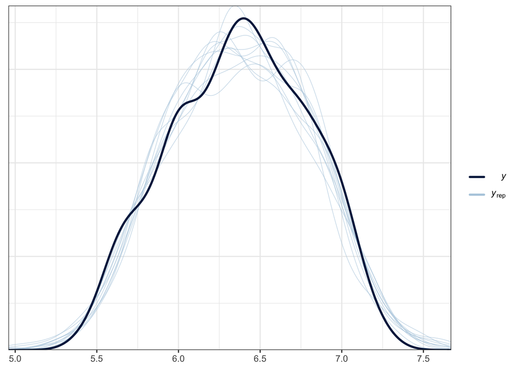

# Compare Frequentist and Bayesian Estimates

```r
b = tidy(bmod3) %>% mutate(model = "Bayesian")
f = tidy(model_f)%>% mutate(model = "Frequentist") # does not give random parameters
both = b %>%
  full_join(f)
  # find duplicates - then remove them . Random parameters cannot be compared with tidy()
both %>%
  dplyr::group_by(term, model) %>%
  dplyr::summarise(n = dplyr::n(), .groups = "drop") %>%
  dplyr::filter(n > 1L)
```

```
## # A tibble: 1 × 3
##   term            model        n
##   <chr>           <chr>    <int>
## 1 sd__(Intercept) Bayesian     3
```

```r
both_wide = both %>%
  filter(!(effect == "ran_pars")) %>%
  dplyr::select( term, model, estimate) %>%
  pivot_wider( names_from = model, values_from = estimate) %>%
  dplyr::select(term,  Bayesian, Frequentist) %>%
  mutate(DifferenceBvsF = Bayesian - Frequentist) %>%
  mutate(across(where(is.numeric), round, 3))
kable(both_wide)
```

| term | Bayesian | Frequentist | DifferenceBvsF |
| --- | --- | --- | --- |
| (Intercept) | 6.564 | 6.561 | 0.002 |
| periodP2 | 0.083 | 0.080 | 0.002 |
| periodP3 | -0.022 | -0.022 | 0.001 |
| periodP4 | 0.177 | 0.179 | -0.002 |
| osc_lvlS | 0.120 | 0.120 | 0.000 |
| prot_lvlLP | 0.084 | 0.084 | 0.000 |
| dayDay2 | 0.057 | 0.059 | -0.002 |
| dayDay3 | 0.106 | 0.108 | -0.002 |
| dayDay4 | -0.044 | -0.043 | -0.001 |
| hr8 | 0.280 | 0.283 | -0.002 |
| hr10 | -0.232 | -0.231 | -0.001 |
| hr12 | -0.447 | -0.447 | 0.000 |
| hr19 | -0.786 | -0.784 | -0.002 |
| osc_lvlS:prot_lvlLP | -0.129 | -0.126 | -0.003 |
| osc_lvlS:dayDay2 | -0.162 | -0.163 | 0.001 |
| osc_lvlS:dayDay3 | -0.249 | -0.249 | 0.001 |
| osc_lvlS:dayDay4 | -0.112 | -0.110 | -0.001 |
| prot_lvlLP:dayDay2 | -0.147 | -0.148 | 0.001 |
| prot_lvlLP:dayDay3 | -0.118 | -0.120 | 0.002 |
| prot_lvlLP:dayDay4 | 0.140 | 0.140 | -0.001 |
| osc_lvlS:hr8 | -0.296 | -0.297 | 0.001 |
| osc_lvlS:hr10 | -0.136 | -0.136 | 0.000 |
| osc_lvlS:hr12 | -0.096 | -0.094 | -0.002 |
| osc_lvlS:hr19 | -0.101 | -0.102 | 0.001 |
| prot_lvlLP:hr8 | -0.362 | -0.364 | 0.002 |
| prot_lvlLP:hr10 | -0.146 | -0.147 | 0.001 |
| prot_lvlLP:hr12 | -0.239 | -0.238 | -0.002 |
| prot_lvlLP:hr19 | -0.043 | -0.044 | 0.001 |
| dayDay2:hr8 | -0.052 | -0.055 | 0.003 |
| dayDay3:hr8 | -0.403 | -0.406 | 0.003 |

[output cut: 53 more lines]

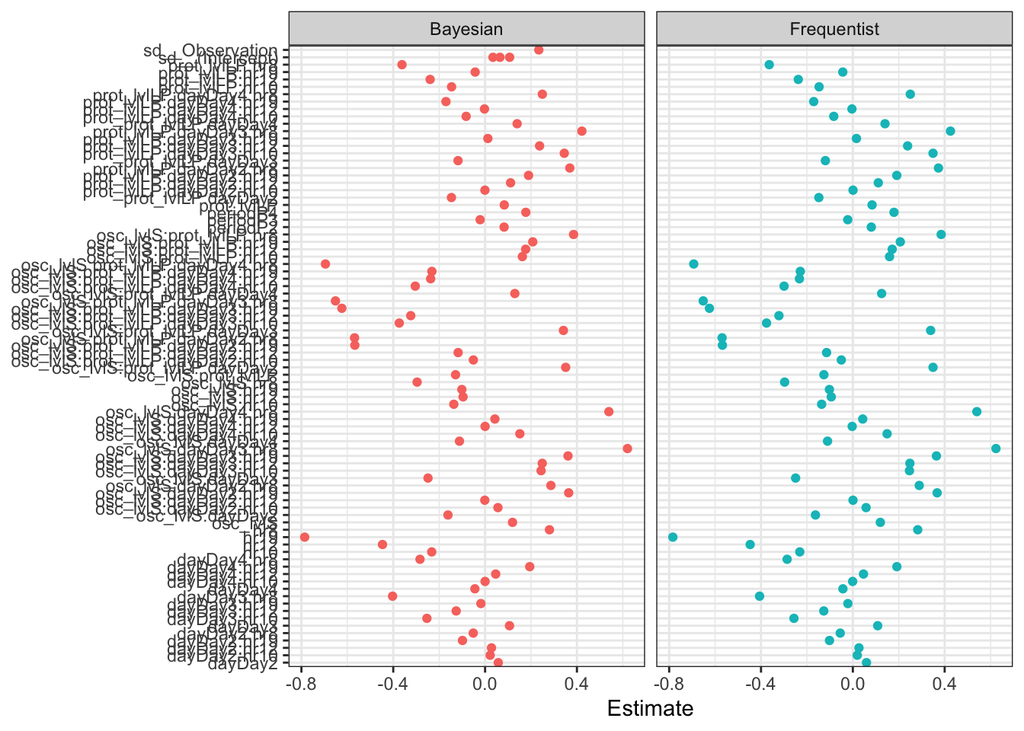

```r
both %>%
  left_join(both_wide) %>%
  filter(term != "(Intercept)") %>%  # much larger than other terms
  ggplot(aes(y = estimate, x = term, color = model)) + # differences are too smale for segment to show up.
  geom_segment(aes(y = estimate - DifferenceBvsF, yend = estimate, xend = term, x = term))+
  geom_point() + coord_flip() + facet_wrap(~model) + theme(legend.position = "none") + labs(x = NULL, y = "Estimate")
```

The fixed effects are very close.

## Visualize autocorrelation

See how the phi parameter affects the degree of autocorrelation, using example data. The first image is close to the estimated phi in our data.

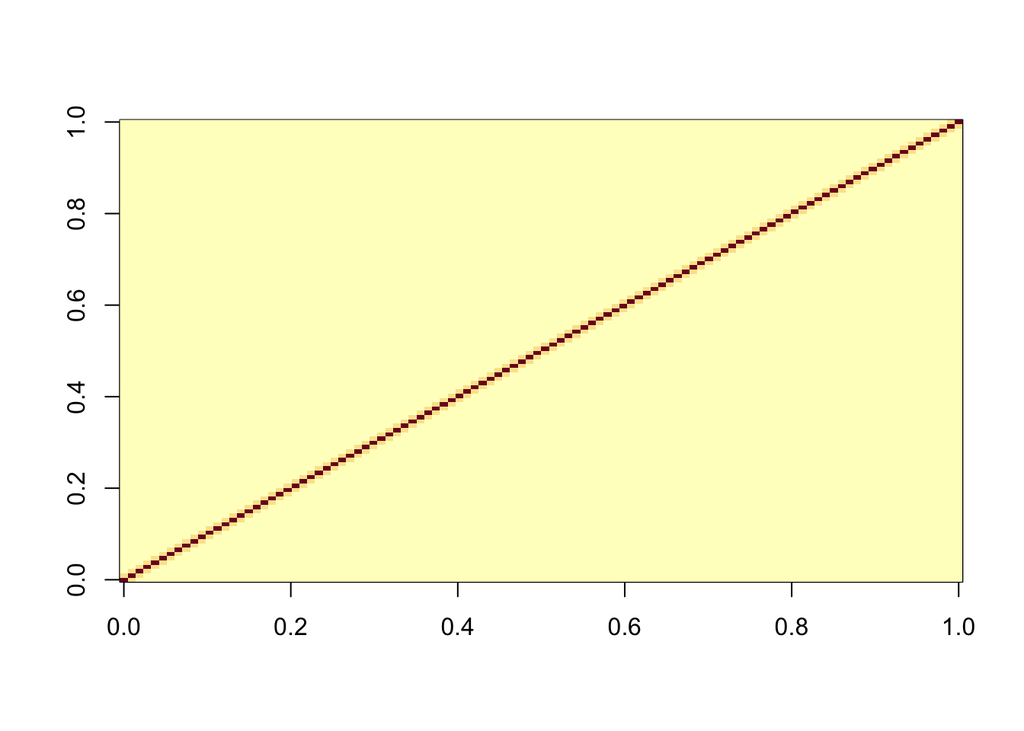

```r
c = corCAR1(value = .2)
cst1 <- Initialize(c, data = Orthodont)
cm = as.matrix(cst1)
image(cm)
```

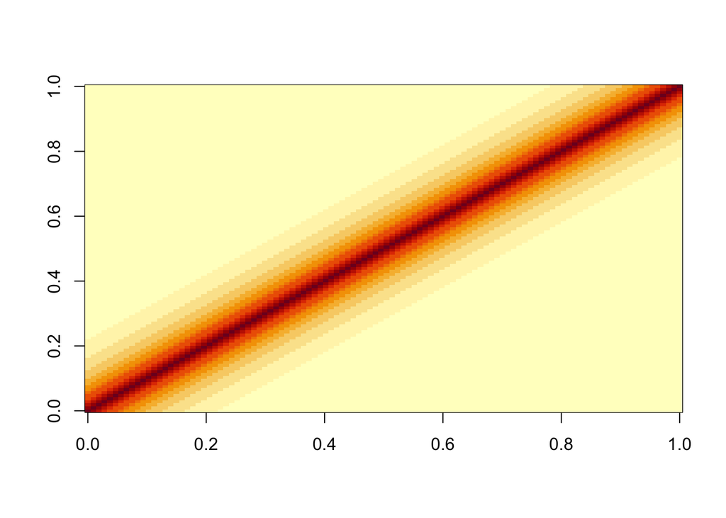

```r
c = corCAR1(value = .9)
cst1 <- Initialize(c, data = Orthodont)
cm = as.matrix(cst1)
image(cm)
```

# Estimated marginal means (emmeans)

## Emmeans with lme()

HPD = highest posterior density region. Defines the credible interval. A credible interval is a section of the posterior distribution.

```r
fem = emmeans(model_f, ~osc_lvl*prot_lvl)
```

```
## NOTE: Results may be misleading due to involvement in interactions
```

```r
fem
```

```
##  osc_lvl prot_lvl emmean     SE df lower.CL upper.CL
##  O       HP         6.37 0.0396  8     6.28     6.46
##  S       HP         6.38 0.0396  8     6.29     6.47
##  O       LP         6.35 0.0396  8     6.25     6.44
##  S       LP         6.38 0.0396  8     6.29     6.47
##
## Results are averaged over the levels of: period, day, hr
## Degrees-of-freedom method: containment
## Confidence level used: 0.95
```

## Emmeans with brms()

HPD = highest posterior density region. Defines the credible interval. A credible interval is a section of the posterior distribution.

```r
bem = emmeans(bmod3, ~osc_lvl*prot_lvl)
```

```
## NOTE: Results may be misleading due to involvement in interactions
```

```r
bem
```

```
##  osc_lvl prot_lvl emmean lower.HPD upper.HPD
##  O       HP         6.37      6.27      6.47
##  S       HP         6.38      6.28      6.47
##  O       LP         6.35      6.25      6.44
##  S       LP         6.38      6.29      6.48
##
## Results are averaged over the levels of: period, day, hr
## Point estimate displayed: median
## HPD interval probability: 0.95
```

## Compare Emmeans

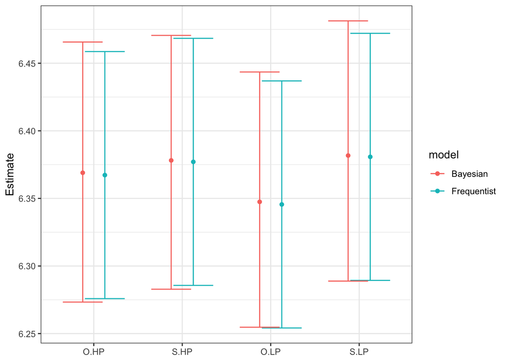

```r
bem1 <- bem %>%
  data.frame() %>%
  rename(
    lower = lower.HPD,
    upper = upper.HPD
  ) %>%
  mutate(model = "Bayesian")
fem1 <- fem %>%
  data.frame() %>%
  rename(
    lower = lower.CL,
    upper = upper.CL
  ) %>%
  mutate(model = "Frequentist")

fem1 %>% full_join(bem1) %>%
  ggplot(aes(x = interaction(osc_lvl, prot_lvl), y = emmean, color = model)) +
  geom_point(position = position_dodge(width = .5)) +
  geom_errorbar(aes(ymin = lower, ymax = upper), position = position_dodge(width = .5)) +
  labs(x = NULL, y = "Estimate")
```

Interestingly, the intervals are slightly wider for Bayesian. Both use 95%.

# Missing data imputation with brms?

There is a way to aggregate multiple imputations from packages such as mice. Alternatively, there is a way to simultaneously impute missing data while modeling. The former is what I was interested in.

# References

Smid, S. C., & Winter, S. D. (2020). Dangers of the defaults: A tutorial on the impact of default priors when using Bayesian SEM with small samples. Frontiers in Psychology, 11, 611963. https://www.frontiersin.org/articles/10.3389/fpsyg.2020.611963/full

https://bookdown.org/marklhc/notes_bookdown/